# CDH phenotypes

Zanis Fang, UID: ZF2213

2/6/2019

### Method

**1. Dealing with missing values.**

```r
# load data and impute several variables
cdh <- readxl::read_xlsx("./CDH_phenotypes.xlsx", sheet = 1, na = ".")
```

There are many missing values in this table. Completeness is different for values collected at different time points.

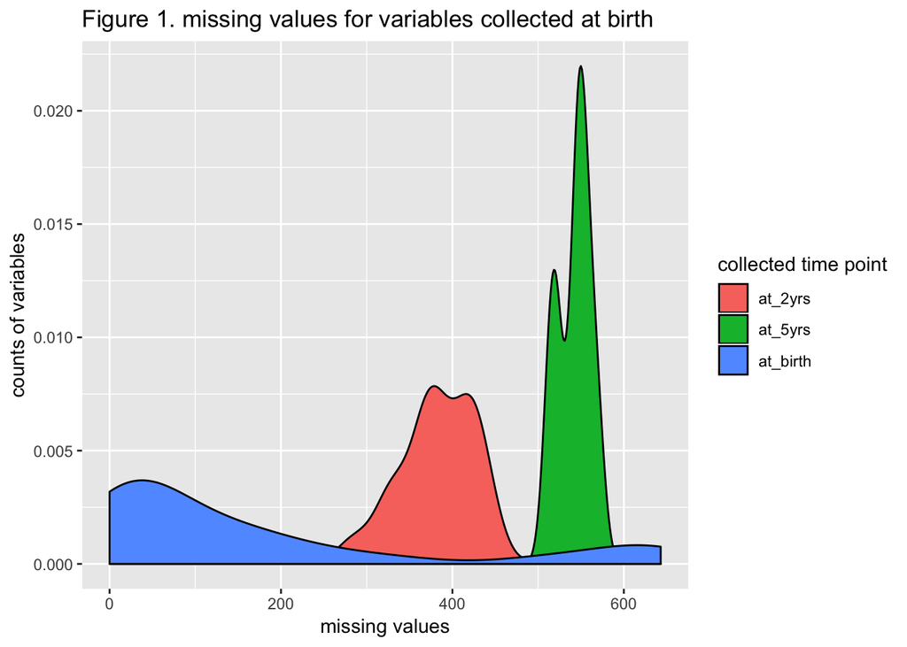

```r
# take a look at intergrity of variables
tibble(
    variables = colnames(cdh),
    missing_values = apply(cdh, 2, FUN = function(x) sum(is.na(x))),
    collect_time =
        c(rep("at_birth", 44), rep("at_2yrs", 19), rep("at_5yrs", 16))) %>%
    ggplot(aes(x = missing_values, fill = collect_time)) +
    geom_density() +
    labs(x = "missing values",
             y = "counts of variables",
             title = "Figure 1. missing values for variables collected at birth",
             fill = "collected time point")
```

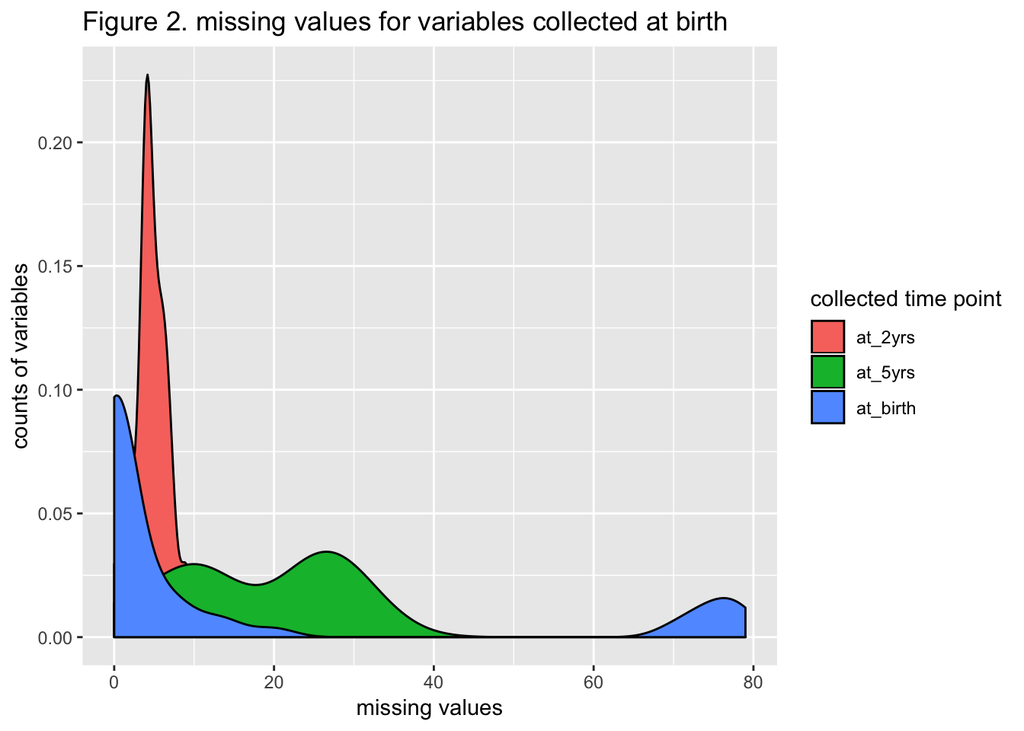

```r
tibble(
    variables = colnames(cdh),
    missing_values = apply(cdh %>% filter(!is.na(crf7_da_fsiq_composite)),
                                                 2, FUN = function(x) sum(is.na(x))),
    collect_time = c(rep("at_birth", 44), rep("at_2yrs", 19), rep("at_5yrs", 16))
) %>%
    ggplot(aes(x = missing_values, fill = collect_time)) +
    geom_density() +
    labs(x = "missing values",
             y = "counts of variables",
             title = "Figure 2. missing values for variables collected at birth",
             fill = "collected time point")
```

I noticed a small peak for variables collected at birth with high percentage of missing values. It turned out to be “gu_anomaly”, “clp”, “need_neo_card_surg”, “sk_anomalies”, “bps”, “ccam”.

Since all of these variables associate with rare situations. It might be reasonable to impute the missing values with 0 (or 2 for need_neo_card_surg).

In this subgroup, the remaining missing values were less severe, so I imputed these small amount of missing values with the median of corresponding columns. I’ll do it in the following chunks.

Variables “dead”, “osp_tracheostomy”, “discharge”, “repaired”, “SampleID”, “dc_dead_age” won’t be used because they are either single-valued or contribute little to model building.

**2. Prediction methods**

I’ll first try to predict IQ using variables collected at birth because of the highest completeness. Then I will use variables collected at either 2-year or at birth to see if it can improve prediction.

The methods I will use are the followin:

- Backward stepwise linear regression (R step function)
- Lasso regression (R glmnet package)
- Sequential neural network (python keras package (in seperate document))

**3. Data cleaning**

First, generating table with only variables collected at birth.

When imputing individually with median, the following variables should be mentioned since they have higher percentage of missing values (more than 20%):

“hh”, “ph1”, “ph3”, “day_28_oxygen”, “hear_2yr”

```r
# data cleaning
cdh_iq_newborn <- cdh %>%
    # get only rows with iq values
    filter(!is.na(crf7_da_fsiq_composite)) %>%
    # select newborn variables
    select(1:44, crf7_da_fsiq_composite) %>%
    # remove less important variables
    select(-dead, -osp_tracheostomy, -discharge,
                 -repaired, -SampleID, -dc_dead_age)

# impute missing values with median of the column
for (i in 1:ncol(cdh_iq_newborn)) {
    cdh_iq_newborn[which(is.na(cdh_iq_newborn[, i])), i] <- median(cdh_iq_newborn[[i]], na.rm = TRUE)
    # turn numeric variables into factor variables
    if (length(unique(cdh_iq_newborn[[i]])) <= 3) {
        cdh_iq_newborn[[i]] <- as.factor(cdh_iq_newborn[[i]])
    }
}

# take a look at cleaned data
# cdh_iq_newborn %>% skimr::skim()

# output for neural network in python
# write_csv(cdh_iq_newborn, "./cdh_iq_newborn.csv")
```

```r
# data cleaning
cdh_iq_2yrs <- cdh %>%
    filter(!is.na(crf7_da_fsiq_composite)) %>%
    select(1:63, crf7_da_fsiq_composite) %>%
    # single value
    select(-dead, -osp_tracheostomy, -discharge,
                 -repaired, -SampleID, -dc_dead_age)

# df_status_tube, fedu, gender, hosp_2yr, medu, income,
# nitric_oxide_therapy, patch, ph1, prenatal_diagnosis,
# ther2yr_any, transfer_inborn

# impute missing values with median of the column
for (i in 1:ncol(cdh_iq_2yrs)) {
    cdh_iq_2yrs[which(is.na(cdh_iq_2yrs[, i])), i] <- median(cdh_iq_2yrs[[i]], na.rm = TRUE)
    # transform to factor
    if (length(unique(cdh_iq_2yrs[[i]])) <= 3) {
        cdh_iq_2yrs[[i]] <- as.factor(cdh_iq_2yrs[[i]])
    }
}

# take a look at cleaned data
# cdh_iq_2yrs %>% skimr::skim()

# output for neural network in python
# write_csv(cdh_iq_2yrs, "./cdh_iq_2yrs.csv")
```

**4. Goals**

I aim at modeling with low training errors (Mean Squared Error, MSE) while keep cross-validation errors low (Mean Squared Prediction Error, MSPE). I will also show the difference between predicted values and collected values. R-squared is calculated to show the percentage of variance in IQ explained by the model.

### Results

*1. Stepwise regression*

Stepwise regression with birth data.

Coefficients and p value for significant variables are listed.

Table 1.

```r
# full model
iq_lm_newborn <- lm(data = cdh_iq_newborn, formula = crf7_da_fsiq_composite ~ .)

# summary(iq_lm_newborn)

iq_newborn_step1 <- step(iq_lm_newborn, direction = "backward", trace = FALSE)
iq_newborn_step1 <- eval(iq_newborn_step1$call)

summary(iq_newborn_step1) %>%
    broom::tidy() %>%
    select(-std.error, -statistic) %>%
    rename(variable = term, coefficient = estimate) %>%
    filter(p.value < 0.1) %>%
    knitr::kable()
```

| variable | coefficient | p.value |
| --- | --- | --- |
| hh | 0.6516988 | 0.0000005 |
| prenatal_diagnosis2 | -9.2108680 | 0.0054355 |
| apgar_1 | 1.2860859 | 0.0389058 |
| sys2 | -13.1039454 | 0.0703525 |
| bps1 | 21.8078002 | 0.0018564 |
| newborn_h_s_abnormal2 | -23.6857493 | 0.0072929 |
| dc_281 | 11.4190635 | 0.0076098 |
| day_28_oxygen2 | -6.5489601 | 0.0333871 |

```r
# par(mfrow = c(2, 2))
# plot(iq_newborn_step1)
```

Stepwise regression with 2-year and birth data.

Coefficients and p value for significant variables are listed.

Table 2.

```r
# full model
iq_lm_2yrs <- lm(data = cdh_iq_2yrs, formula = crf7_da_fsiq_composite ~ .)

iq_2yrs_step1 <- step(iq_lm_2yrs, direction = "backward", trace = FALSE)
iq_2yrs_step1 <- eval(iq_2yrs_step1$call)

summary(iq_2yrs_step1) %>%
    broom::tidy() %>%
    select(-std.error, -statistic) %>%
    rename(variable = term, coefficient = estimate) %>%
    filter(p.value < 0.1) %>%
    knitr::kable()
```

| variable | coefficient | p.value |
| --- | --- | --- |
| race21 | -8.9027596 | 0.0353066 |
| medu1 | -8.4683722 | 0.0282894 |
| hh | 0.4639103 | 0.0035555 |
| gender2 | -5.8423282 | 0.0478903 |
| prenatal_diagnosis2 | -6.7624429 | 0.0301729 |
| ht_z_birth | 4.0799072 | 0.0027308 |
| chd1 | 8.7632276 | 0.0751708 |
| gi1 | -16.0416005 | 0.0786897 |
| sk_anomalies1 | 22.0695867 | 0.0149443 |
| bps1 | 16.0897225 | 0.0215274 |
| newborn_h_s_abnormal2 | -21.2301097 | 0.0129304 |
| day_28_oxygen2 | 7.8358834 | 0.0493344 |
| discharge_oxygen2 | -8.1722963 | 0.0848995 |
| waz_2yr | -3.2867272 | 0.0119634 |
| headcz_2yr | 3.4208737 | 0.0110770 |
| hosp_2yr1 | 6.2550180 | 0.0511617 |
| ther2yr_any1 | -11.8419764 | 0.0006373 |
| tube_2yr1 | -17.1598587 | 0.0071276 |
| da_age | 2.1782867 | 0.0055892 |
| da_lang_composite_score | 0.2870704 | 0.0830738 |
| age_at_vine_ii_eval | -1.4905857 | 0.0233518 |
| vabs_com_stand_score | 0.6399698 | 0.0108249 |
| vabs_dai_liv_stand_score | -0.4234547 | 0.0279972 |

```r
# par(mfrow = c(2, 2))
# plot(iq_2yrs_step1)
```

Cross-validation of the two models

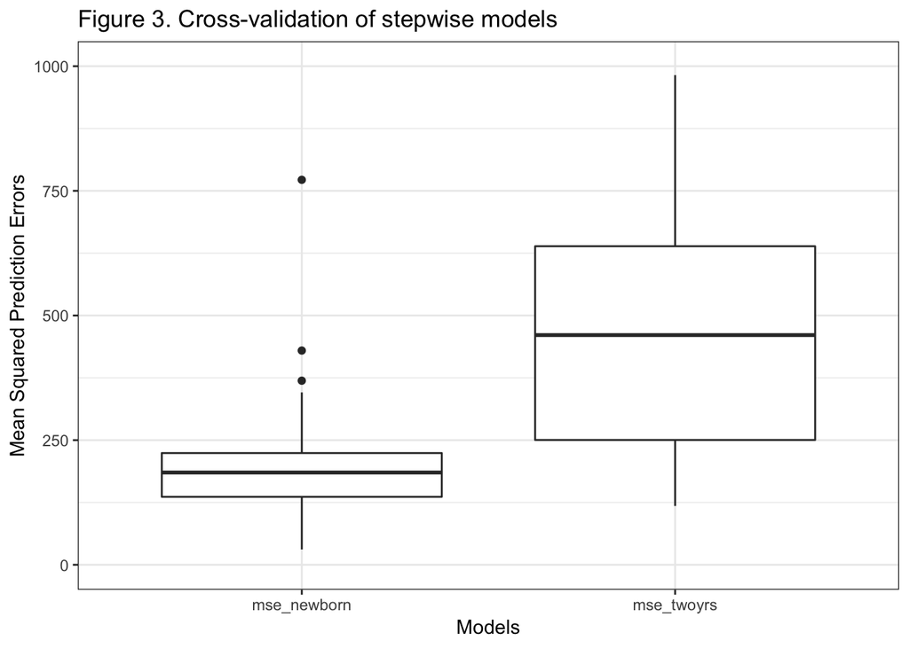

```r
formula1 <- get_lm_model(iq_newborn_step1)
formula2 <- get_lm_model(iq_2yrs_step1)

cv_df =
  modelr::crossv_mc(cdh, 100) %>%
  mutate(train = map(train, as_tibble), test = map(test, as_tibble)) %>%
  mutate(newborn = map(train, ~lm(formula = as.formula(formula1), data = .x)),
         twoyrs = map(train, ~lm(formula = as.formula(formula2), data = .x))
             )

cv_df <- cv_df %>%
  mutate(mse_newborn =
           map2_dbl(newborn, test, ~(modelr::rmse(model = .x, data = .y))^2),
         mse_twoyrs =
           map2_dbl(twoyrs, test, ~(modelr::rmse(model = .x, data = .y))^2)
         ) %>%
  select(starts_with("mse")) %>%
  gather(key = model, value = mse) %>%
  mutate(model = recode(model, mse_step1 = "Newborn",
                        mse_step2 = "Two Years"
                                            ))

cv_df %>% ggplot(aes(x = model, y = mse)) + geom_boxplot() +
  labs(
    x = "Models",
    y = "Mean Squared Prediction Errors",
    title = "Figure 3. Cross-validation of stepwise models"
  ) +
  theme_bw() +
    ylim(0, 1000)
```

*2. Lasso regression*

Use cross-validation to determine penalty term lambda for the lasso regression.

Using birth data.

Figure 4.

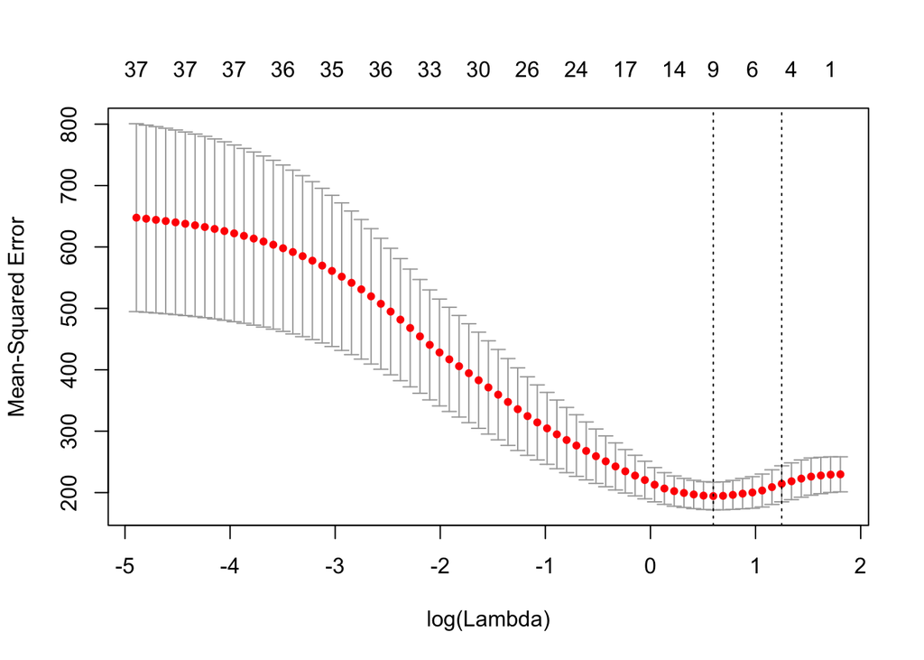

```r
lasso_birth_out <- data.matrix(cdh_iq_newborn[, 39])
lasso_birth_pred <- data.matrix(cdh_iq_newborn[, 1:38])

# crossvalidation
set.seed(37)
cv_lasso_birth <- glmnet::cv.glmnet(lasso_birth_pred,
                                                                        lasso_birth_out, alpha = 1)

# plot crossvalidation
par(mfrow = c(1, 1))
plot(cv_lasso_birth)
```

```r
# get model with least MPSE
lasso_birth <- glmnet::glmnet(lasso_birth_pred, lasso_birth_out,
                                                            alpha = 1, lambda = cv_lasso_birth$lambda.min)

# y_hat
lasso_yhat_birth <- cbind(1, lasso_birth_pred) %*% as.matrix(coef(lasso_birth))

# r squared
rsq_lasso_birth = 1 - var(lasso_yhat_birth - lasso_birth_out) /
    var(lasso_birth_out)

# MSE
mse_lasso_birth <- sum((lasso_yhat_birth - lasso_birth_out)^2) / 79

# MPSE
mspe_high_lasso_birth <- cv_lasso_birth$cvup[which(cv_lasso_birth$lambda == cv_lasso_birth$lambda.min)]
mpse_low_lasso_birth <- cv_lasso_birth$cvlo[which(cv_lasso_birth$lambda == cv_lasso_birth$lambda.min)]
mpse_lasso_birth <- cv_lasso_birth$cvm[which(cv_lasso_birth$lambda == cv_lasso_birth$lambda.min)]

# coefficients
lasso_birth$beta %>%
    broom::tidy() %>%
    rename(variable = row, coefficients = value) %>%
    select(-column) %>%
    knitr::kable()
```

| variable | coefficients |
| --- | --- |
| hh | 0.3585232 |
| transfer_inborn | 0.6986741 |
| prenatal_diagnosis | -2.2368729 |
| apgar_1 | 0.0019289 |
| cns | -2.0155855 |
| bps | 3.4642493 |
| newborn_h_s_abnormal | -16.1412421 |
| dc_28 | 4.1115409 |
| dc_alive_age | -0.0489990 |

Using birth and 2-year data.

Figure 5.

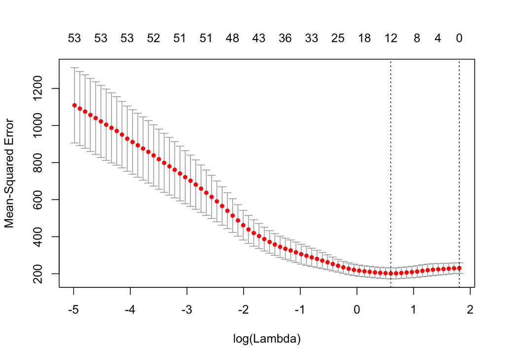

```r
lasso_2yrs_out <- data.matrix(cdh_iq_2yrs[, 58])
lasso_2yrs_pred <- data.matrix(cdh_iq_2yrs[, 1:57])

# crossvalidation
set.seed(37)
cv_lasso_2yrs <- glmnet::cv.glmnet(lasso_2yrs_pred, lasso_2yrs_out, alpha = 1)

# plot crossvalidation
par(mfrow = c(1, 1))
plot(cv_lasso_2yrs)
```

```r
# get model with least MPSE
lasso_2yrs <- glmnet::glmnet(lasso_2yrs_pred, lasso_2yrs_out,
                                   alpha = 1, lambda = cv_lasso_2yrs$lambda.min)

# y_hat
lasso_yhat_2yrs <- cbind(1, lasso_2yrs_pred) %*% as.matrix(coef(lasso_2yrs))

# r squared
rsq_lasso_2yrs = 1 - var(lasso_yhat_2yrs - lasso_2yrs_out) / var(lasso_2yrs_out)

# MSE
mse_lasso_2yrs <- sum((lasso_yhat_2yrs - lasso_2yrs_out)^2) / 79


# MPSE
mspe_high_lasso_2yrs <- cv_lasso_2yrs$cvup[which(cv_lasso_2yrs$lambda == cv_lasso_2yrs$lambda.min)]
mpse_low_lasso_2yrs <- cv_lasso_2yrs$cvlo[which(cv_lasso_2yrs$lambda == cv_lasso_2yrs$lambda.min)]
mpse_lasso_2yrs <- cv_lasso_2yrs$cvm[which(cv_lasso_2yrs$lambda == cv_lasso_2yrs$lambda.min)]

# coefficients
lasso_2yrs$beta %>%
    broom::tidy() %>%
    rename(variable = row, coefficients = value) %>%
    select(-column) %>%
    knitr::kable()
```

| variable | coefficients |
| --- | --- |
| hh | 0.2897526 |
| transfer_inborn | 1.7931202 |
| prenatal_diagnosis | -2.4160962 |
| cns | -0.6089839 |
| bps | 3.1698078 |
| newborn_h_s_abnormal | -14.5778599 |
| dc_28 | 3.5915624 |
| dc_alive_age | -0.0203986 |
| ther2yr_any | -3.0255247 |
| da_lang_composite_score | 0.1425487 |
| da_cog_composite_score | 0.0438073 |
| vabs_com_stand_score | 0.0529395 |

*3. Deep learning*

Deep learning performance

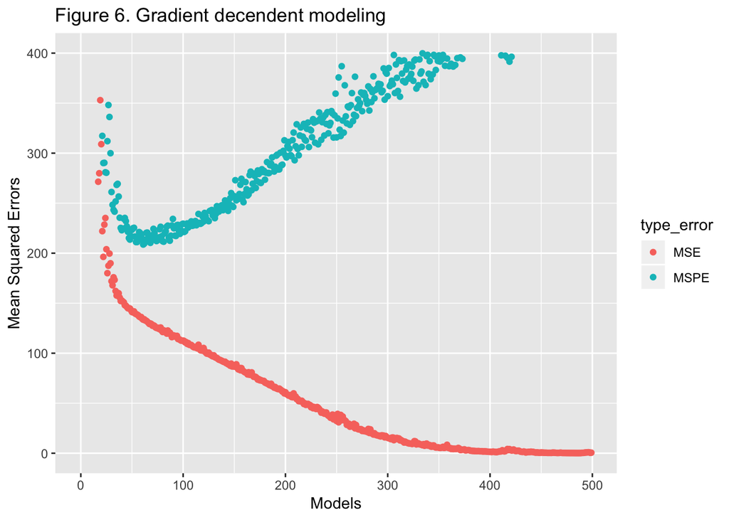

```r
dl_epoch_birth <- read_csv("./history_newborn.csv") %>%
    rename(epoch = X1, MSPE = val_loss, MSE = loss)

dl_epoch_birth %>%
    gather(key = type_error, value = error, 2:3) %>%
    ggplot(aes(x = epoch, y = error, color = type_error)) +
    geom_point() +
    # geom_line() +
    ylim(0, 400) +
    labs(
    x = "Models",
    y = "Mean Squared Errors",
    title = "Figure 6. Gradient decendent modeling"
  )
```

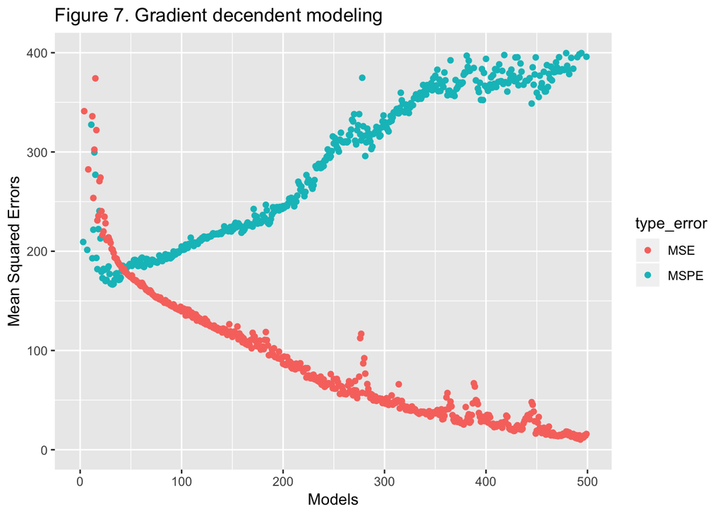

```r
# dl_epoch_birth[101,]

dl_epoch_2yrs <- read_csv("./history_2yrs.csv") %>%
    rename(epoch = X1, MSPE = val_loss, MSE = loss)

dl_epoch_2yrs %>%
    gather(key = type_error, value = error, 2:3) %>%
    ggplot(aes(x = epoch, y = error, color = type_error)) +
    geom_point() +
    # geom_line() +
    ylim(0, 400) +
    labs(
    x = "Models",
    y = "Mean Squared Errors",
    title = "Figure 7. Gradient decendent modeling"
  )
```

### Summary

**1. Distribution of the difference between predicted values (Y_hat) and true values (Y) for different models**

**iq_dist: original IQ distribution centered with mean IQ.**

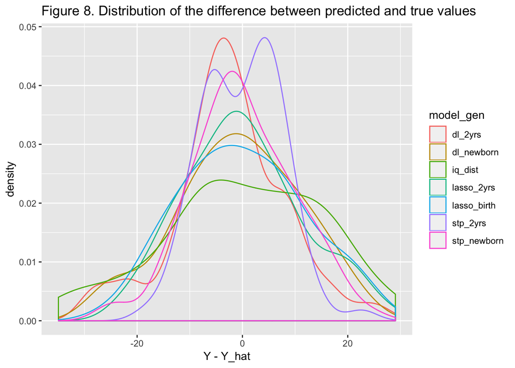

```r
predicted_dl_newborn <-
    read_csv("./predicted_newborn.csv") %>%
    select(Y_hat, Y) %>%
    mutate(model_gen = "dl_newborn")

predicted_dl_2yrs <-
    read_csv("./predicted_2yrs.csv") %>%
    select(Y_hat, Y) %>%
    mutate(model_gen = "dl_2yrs")

predicted_step_newborn <- tibble(
    Y_hat = iq_newborn_step1$fitted.values,
    Y = iq_newborn_step1$model[, 1],
    model_gen = "stp_newborn"
)

predicted_step_2yrs <- tibble(
    Y_hat = iq_2yrs_step1$fitted.values,
    Y = iq_2yrs_step1$model[, 1],
    model_gen = "stp_2yrs"
)

predicted_lasso_2yrs <- tibble(
    Y_hat = lasso_yhat_2yrs,
    Y = lasso_2yrs_out,
    model_gen = "lasso_2yrs"
)

predicted_lasso_birth <- tibble(
    Y_hat = lasso_yhat_birth,
    Y = lasso_birth_out,
    model_gen = "lasso_birth"
)

iq <- cdh$crf7_da_fsiq_composite[which(!is.na(cdh$crf7_da_fsiq_composite))]

iq_dist <- tibble(
    Y_hat = iq,
    Y = mean(cdh$crf7_da_fsiq_composite, na.rm = TRUE),
    model_gen = "iq_dist"
)

temp_a <- rbind(predicted_dl_newborn, predicted_dl_2yrs)
temp_b <- rbind(predicted_step_newborn, predicted_step_2yrs)
temp_c <- rbind(predicted_lasso_birth, predicted_lasso_2yrs)
dl <- rbind(temp_a, temp_b)
dl <- rbind(dl, temp_c)

dl <- rbind(dl, iq_dist)

dl %>%
    ggplot(aes(x = Y - Y_hat, color = model_gen)) +
    geom_density() +
    labs(
        title = "Figure 8. Distribution of the difference between predicted and true values"
    )
```

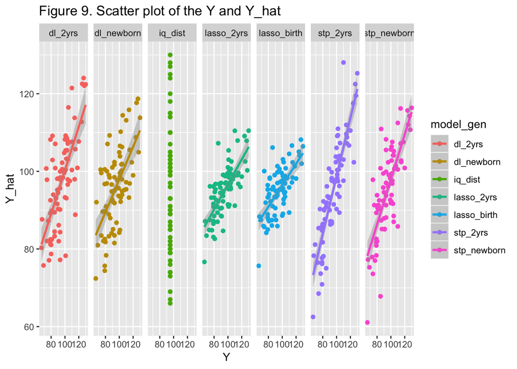

```r
dl %>%
    ggplot(aes(x = Y, y = Y_hat, color = model_gen)) +
    geom_point() +
    geom_smooth(method = "lm") +
    facet_grid(. ~ model_gen) +
    labs(
        title = "Figure 9. Scatter plot of the Y and Y_hat"

    )
```

**2. MSE (training bias) MPSE (out-sample bias) and R-squared**

```r
# R squared

rsq <- c(
    summary(iq_2yrs_step1)$adj.r.squared,
    summary(iq_newborn_step1)$adj.r.squared,
    rsq_lasso_birth[1],
    rsq_lasso_2yrs[1],
    1 - var(predicted_dl_newborn$Y_hat - predicted_dl_newborn$Y) /
        var(predicted_dl_newborn$Y),
    1 - var(predicted_dl_2yrs$Y_hat - predicted_dl_2yrs$Y) /
        var(predicted_dl_2yrs$Y)
)

# MSE

mse <- c(
    sum(iq_newborn_step1$residuals^2) / 79,
    sum(iq_2yrs_step1$residuals^2) / 79,
    mse_lasso_birth,
    mse_lasso_2yrs,
    sum((predicted_dl_newborn$Y_hat - predicted_dl_newborn$Y)^2) / 79,
    sum((predicted_dl_2yrs$Y_hat - predicted_dl_2yrs$Y)^2) / 79
)

# MSPE

summarise_step <- cv_df %>% group_by(model) %>% summarise(median = median(mse), min = min(mse), max = max(mse))

mspe <- c(
    summarise_step[1, 2][[1]],
    summarise_step[2, 2][[1]],
    mpse_lasso_birth[[1]],
    mpse_lasso_2yrs[[1]],
    dl_epoch_birth[101, 2][[1]],
    dl_epoch_2yrs[201, 2][[1]]
)

tibble(
    model = c("Stepwise birth",
                        "Stepwise 2-year",
                        "Lasso birth",
                        "Lasso 2-year",
                        "Deeplearning birth",
                        "Deeplearning 2-year"),
    rsq = rsq,
    mse = mse,
    mspe = mspe

) %>% knitr::kable()
```

| model | rsq | mse | mspe |
| --- | --- | --- | --- |
| Stepwise birth | 0.5738527 | 93.56104 | 185.0976 |
| Stepwise 2-year | 0.4793910 | 55.91913 | 532.6694 |
| Lasso birth | 0.3815960 | 137.59722 | 194.3534 |
| Lasso 2-year | 0.4458560 | 123.29912 | 201.8027 |
| Deeplearning birth | 0.3831679 | 137.83556 | 229.4835 |
| Deeplearning 2-year | 0.4896157 | 119.50004 | 245.5047 |

### Conclusion

According to Figure 9, all the models at least out-performed null model (predict the IQ values with mean IQ). But all the models has higher out-sample error (MSPE) in comparison with training error (MSE). It is not confident whether the models would have some prediction values.